# Correction du sujet blanc du TD noté : modèles de comptage, de choix discrets et de durée (R)

- Montrer tout le code
- Cacher tout le code
- Voir les sources

Année universitaire 2026–2027 • Parcours Économie de la santé & Développement durable

Correction détaillée et barème du sujet blanc

Auteur·rice

Pierre Beaucoral

```r
knitr::opts_chunk$set(fig.width = 7, fig.height = 4, fig.align = "center")

library(AER)               # NMES1988
library(MASS)              # glm.nb, polr
library(nnet)              # multinom
library(ordinal)           # clm, nominal_test
library(ResourceSelection) # hoslem.test
library(pROC)              # roc, auc
library(survival)          # Surv, survfit, coxph, survreg, colon
library(survminer)         # ggsurvplot

data("NMES1988", package = "AER")
nmes <- NMES1988
nmes$health <- factor(nmes$health, levels = c("average", "poor", "excellent"))

colon_d <- subset(survival::colon, etype == 2 & !is.na(nodes))

# Nombres cités dans le texte : virgule décimale
fmt <- function(x, d = 2) {
  formatC(as.numeric(x), format = "f", digits = d,
          decimal.mark = ",", big.mark = " ")
}
fp <- function(p) ifelse(p < 0.001, "< 0,001", paste("=", fmt(p, 3)))
fpct <- function(x, d = 1) paste0(fmt(100 * x, d), " %")
```

**ImportantBarème et règles de notation**

Cette correction donne, pour chaque question, le code, les sorties, la réponse attendue et le barème. Les nombres du texte sont calculés par R au moment du rendu. Le barème totalise 20 points (A : 7, B : 7, C : 6) plus 4 points de bonus (D), note plafonnée à 20.

**Règle générale de notation.** Le code seul ne rapporte rien : les points vont à la justification (choix du modèle, degrés de liberté, hypothèses) et à l’interprétation rédigée. L’exemple de l’aide `?NMES1988` ajuste un Poisson et une binomiale négative sur `visits` avec d’autres variables : un étudiant qui le recopie sans adapter la spécification ni interpréter n’obtient pas les points de A6–A8.

**Erreur reportée.** Plusieurs questions dépendent d’un choix fait plus tôt (A6 → A7–A8 ; B4–B5 → B6–B7 ; C3 → C4–C6). On note chaque réponse **en cohérence avec le modèle que l’étudiant a lui-même retenu** : une erreur n’est sanctionnée qu’une fois, là où elle est commise.

# Partie A : Modèles de comptage [7 points]

**Le modèle.** La variable expliquée est un **comptage** (0, 1, 2, … consultations). Le modèle de Poisson suppose

$$Y_i \sim \mathcal{P}(\mu_i), \qquad \mu_i = E(Y_i \mid X_i) = \exp(X_i'\beta),
\qquad \text{Var}(Y_i \mid X_i) = \mu_i .$$

$\mu_i$ est le nombre **espéré** de consultations de l’individu $i$ compte tenu de ses caractéristiques. Dans R, ce sont les valeurs ajustées `fitted(modele)`. L’exponentielle garantit $\mu_i > 0$. Elle rend aussi les effets **multiplicatifs** : $\exp(\beta_k)$ est le facteur par lequel $\mu_i$ est multiplié quand $x_k$ augmente d’une unité. C’est le **ratio de taux** (IRR, *incidence rate ratio*).

**Ce que teste la partie.** A.1 : l’offset quand les unités n’ont pas la même exposition, et le test d’ajustement sur données agrégées. A.2 : la sur-dispersion (variance > moyenne), ses conséquences sur les écarts-types et la binomiale négative comme remède.

## A.1 Données agrégées et offset [3 points]

### A1 : Cellules et taux [0,5]

> **Énoncé.** Combien y a-t-il de cellules ? Calculer, pour chaque cellule, le nombre moyen de consultations par personne. Pourquoi ne peut-on pas comparer directement les totaux `visits` entre cellules ?

**L’idée.** Un total dépend de deux choses : l’intensité du phénomène (le taux) et la taille de la population exposée. Pour comparer des groupes de tailles différentes, il faut raisonner en taux.

```r
cells <- aggregate(cbind(visits, n = 1) ~ health + adl + insurance + gender,
                   data = nmes, FUN = sum)
cells$taux <- cells$visits / cells$n
nrow(cells)
```

```
[1] 24
```

```r
summary(cells$n)
```

```
   Min. 1st Qu.  Median    Mean 3rd Qu.    Max.
    1.0    31.0    83.0   183.6   142.5  1362.0
```

```r
cells[order(cells$taux), ][c(1:3, 22:24), ]
```

```
      health     adl insurance gender visits  n      taux
6  excellent limited        no female      6  6  1.000000
15 excellent  normal        no   male     47 28  1.678571
18 excellent limited        no   male      2  1  2.000000
5       poor limited        no female    896 95  9.431579
8       poor  normal       yes female    884 92  9.608696
20      poor  normal       yes   male    740 74 10.000000
```

Il y a **24 cellules** (3 × 2 × 2 × 2, toutes non vides), d’effectifs très inégaux : de 1 à 1 362 personnes. Le nombre moyen de consultations par personne va de 1,0 à 10,0 selon la cellule. Certaines cellules sont minuscules (1 personne pour la plus petite) : leurs taux sont très imprécis. Le modèle de Poisson pondère naturellement chaque cellule par son effectif.

On ne peut pas comparer les **totaux** : une cellule de 1 362 personnes cumule mécaniquement beaucoup plus de consultations qu’une cellule de 1 personne. La grandeur comparable est le **taux** = consultations / personnes-années.

**NoteBarème A1 (0,5)**

0,25 : nombre de cellules et taux par cellule. 0,25 : argument de l’exposition (effectifs) différente selon les cellules.

### A2 : Poisson avec offset [1]

> **Énoncé.** Ajuster le modèle de Poisson de `visits` sur `health`, `adl`, `insurance` et `gender`, avec l’offset approprié. Écrire l’équation du modèle et expliquer le rôle de l’offset. Calculer le ratio de taux (IRR) associé à `insurance`, avec son intervalle de confiance à 95 %, et l’interpréter.

**L’idée.** On veut modéliser le **taux** $\mu_c / n_c$, mais `glm()` modélise l’espérance du **total** $\mu_c$. Comme $\log(\mu_c/n_c) = X_c'\beta$ équivaut à $\log \mu_c = \log n_c + X_c'\beta$, il suffit d’ajouter $\log n_c$ au prédicteur avec un coefficient **imposé** à 1 : c’est l’offset.

```r
m_cell <- glm(visits ~ health + adl + insurance + gender + offset(log(n)),
              family = poisson, data = cells)
summary(m_cell)$coefficients
```

```
                   Estimate Std. Error    z value      Pr(>|z|)
(Intercept)      1.46778525 0.01661372  88.347791  0.000000e+00
healthpoor       0.45498132 0.01730727  26.288448 2.599519e-152
healthexcellent -0.46433106 0.03007859 -15.437259  9.192454e-54
adllimited       0.16623390 0.01574212  10.559818  4.575466e-26
insuranceyes     0.30119239 0.01625473  18.529521  1.193441e-76
gendermale      -0.08963463 0.01301451  -6.887286  5.686686e-12
```

```r
b_ic  <- coef(m_cell)["insuranceyes"]
se_ic <- sqrt(vcov(m_cell)["insuranceyes", "insuranceyes"])
irr_c    <- exp(b_ic)
irr_c_ci <- exp(b_ic + c(-1, 1) * qnorm(0.975) * se_ic)
c(IRR = irr_c, IC_inf = irr_c_ci[1], IC_sup = irr_c_ci[2])
```

```
IRR.insuranceyes           IC_inf           IC_sup
        1.351469         1.309092         1.395219
```

**Équation.** Avec $Y_c$ le total de consultations de la cellule $c$ et $n_c$ son effectif (personnes-années) :

$$\begin{aligned}
Y_c &\sim \mathcal{P}(\mu_c), \\
\log \mu_c &= \log n_c + \beta_0 + \beta_1\,\mathbb{1}\{\text{poor}\}_c
+ \beta_2\,\mathbb{1}\{\text{excellent}\}_c \\
&\quad + \beta_3\,\mathbb{1}\{\text{limited}\}_c
+ \beta_4\,\mathbb{1}\{\text{insurance}\}_c + \beta_5\,\mathbb{1}\{\text{male}\}_c
\end{aligned}$$

soit $\mu_c / n_c = \exp(\beta_0 + \dots)$. L’**offset** $\log n_c$ est une variable de coefficient fixé à 1 : le modèle porte sur le **nombre de consultations par personne-année**, et non sur le total de la cellule. Sans offset, les coefficients capteraient aussi la taille des cellules.

**IRR.** L’IC de l’IRR s’obtient en passant à l’exponentielle les bornes de l’IC de $\beta$ (et non en ajoutant ± 1,96 écart-type à l’IRR lui-même). À santé perçue, limitation et sexe donnés, les personnes couvertes par une complémentaire ont un nombre **espéré** de consultations par personne-année multiplié par **1,35** (IC 95 % : 1,31 à 1,40), soit environ 35 % de plus. Cet IC est calculé sous l’hypothèse de Poisson, qu’A3 va remettre en cause.

**NoteBarème A2 (1)**

0,25 : modèle ajusté avec `offset(log(n))` (ou l’argument `offset =`). 0,25 : équation et rôle de l’offset. 0,5 : IRR, IC et interprétation « toutes choses égales par ailleurs ».

### A3 : Ajustement [1]

> **Énoncé.** Tester l’ajustement du modèle par la déviance et par la statistique de Pearson. Justifier les degrés de liberté et vérifier les conditions d’application du test du $\chi^2$. Conclure, et en déduire le paramètre de dispersion $\hat\phi$ (statistique de Pearson / ddl). Quelle conséquence le résultat a-t-il sur les écarts-types de A2 ?

**L’idée.** Les deux statistiques comparent le modèle au modèle **saturé** (un paramètre par cellule, qui reproduit parfaitement les données) :

- la **déviance** $D = 2(\ell_{\text{saturé}} - \ell_{\text{modèle}})$ mesure ce que l’on perd en vraisemblance ;
- la statistique de **Pearson** $X^2 = \sum_c (y_c - \hat\mu_c)^2 / \hat\mu_c$ additionne les écarts au carré, chacun rapporté à la variance prévue par le Poisson ($\text{Var} = \mu$).

Si le modèle est correct, les deux suivent approximativement un $\chi^2$ à (nombre de cellules − $p$) ddl et valent donc environ ce nombre de ddl. Le rapport $\hat\phi = X^2/\text{ddl}$ devrait alors être proche de 1. S’il vaut $\phi$, la variance réelle est $\phi$ fois celle du Poisson, et les écarts-types sont $\sqrt{\phi}$ fois trop petits (un écart-type est la racine d’une variance).

```r
dev_c  <- deviance(m_cell)
pear_c <- sum(residuals(m_cell, type = "pearson")^2)
df_c   <- df.residual(m_cell)
c(deviance = dev_c, pearson = pear_c, ddl = df_c,
  p_dev = pchisq(dev_c, df_c, lower.tail = FALSE),
  p_pearson = pchisq(pear_c, df_c, lower.tail = FALSE))
```

```
    deviance      pearson          ddl        p_dev    p_pearson
2.018538e+02 1.997525e+02 1.800000e+01 4.265815e-33 1.122888e-32
```

```r
n_small_c <- sum(fitted(m_cell) < 5)
c(min_ajuste = min(fitted(m_cell)), n_inf_5 = n_small_c)
```

```
min_ajuste    n_inf_5
  2.944837   1.000000
```

```r
phi_c <- pear_c / df_c
# même modèle sur données individuelles, pour comparaison
m_ind4 <- glm(visits ~ health + adl + insurance + gender, family = poisson, data = nmes)
pear_ind4 <- sum(residuals(m_ind4, type = "pearson")^2) / df.residual(m_ind4)
q_cell <- glm(visits ~ health + adl + insurance + gender + offset(log(n)),
              family = quasipoisson, data = cells)
# IC de Wald (loi normale) ; summary() utilise une loi de Student
irr_c_ci_q <- exp(b_ic + c(-1, 1) * qnorm(0.975) *
                    sqrt(vcov(q_cell)["insuranceyes", "insuranceyes"]))
c(phi = phi_c, IC_inf = irr_c_ci_q[1], IC_sup = irr_c_ci_q[2])
```

```
      phi    IC_inf    IC_sup
11.097359  1.215387  1.502788
```

- **Degrés de liberté** : 24 cellules − 6 paramètres = **18**. Le modèle saturé a un paramètre par cellule.
- Déviance = 201,9 et Pearson = 199,8, pour 18 ddl : p-values < 0,001.
- **Conditions d’application** : les comptes attendus doivent être assez grands (au moins 5). Ici 1 cellule sur 24 a un compte ajusté inférieur à 5 (2,9) : la condition est quasiment remplie. C’est l’avantage des données agrégées (voir le piège ci-dessous).

**Conclusion** : on rejette nettement l’adéquation du modèle, avec $\hat\phi$ = 11,1. Deux sources possibles, non exclusives :

1. une **sur-dispersion individuelle** : à caractéristiques données, le nombre de consultations varie d’une personne à l’autre plus que ne le permet une loi de Poisson (hétérogénéité non observée *aléatoire*, qui s’additionne dans les totaux) ;
2. une **moyenne mal spécifiée** : le modèle n’a que des effets principaux (pas d’interactions) et les cellules diffèrent par leur composition (nombre de maladies chroniques, âge, revenu).

Attention : des différences *fixes* entre individus d’une même cellule ne suffisent pas à elles seules à créer de la sur-dispersion, car une somme de variables de Poisson indépendantes reste une variable de Poisson. $\hat\phi$ (11,1) dépasse d’ailleurs le Pearson/ddl du même modèle estimé sur données individuelles (7,3) : une partie du rejet vient donc sans doute de la moyenne. Le correctif quasi-Poisson suppose, lui, la moyenne bien spécifiée. **Conséquence** : les écarts-types de A2 sont sous-estimés d’un facteur 3,3 (racine carrée de $\hat\phi$). En quasi-Poisson, l’IC de l’IRR de `insurance` devient 1,22 à 1,50 : plus large, mais il exclut toujours 1.

**AvertissementPiège fréquent**

Faire le test du $\chi^2$ de la déviance sur les **données individuelles**. Avec un individu par « cellule », les comptes attendus sont petits et le nombre de paramètres du modèle saturé croît avec $n$ : la déviance ne suit plus un $\chi^2$ et le test n’a pas de sens. Sur données individuelles, on regarde plutôt Pearson / ddl comme un indicateur de sur-dispersion (A6), sans en tirer de p-value.

**NoteBarème A3 (1)**

0,25 : deux statistiques et p-values. 0,25 : ddl justifiés (24 cellules − 6 paramètres). 0,25 : conditions d’application (comptes attendus). 0,25 : conclusion (rejet), $\hat\phi$ et conséquence sur les écarts-types. On accepte l’une ou l’autre explication du rejet (sur-dispersion individuelle ou moyenne mal spécifiée) ; l’IC quasi-Poisson est un plus, non exigé.

### A4 : Données agrégées contre données individuelles [0,5]

> **Énoncé.** Ajuster le même modèle de Poisson (mêmes quatre variables) sur les **données individuelles** `nmes`, sans offset. Comparer coefficients et écarts-types avec ceux de A2. Expliquer.

**L’idée.** Quand les variables explicatives sont constantes dans une cellule, agréger ne fait perdre aucune information au Poisson.

```r
m_ind <- glm(visits ~ health + adl + insurance + gender,
             family = poisson, data = nmes)
round(cbind(coef_cellules = coef(m_cell), coef_individus = coef(m_ind),
            se_cellules = sqrt(diag(vcov(m_cell))),
            se_individus = sqrt(diag(vcov(m_ind)))), 5)
```

```
                coef_cellules coef_individus se_cellules se_individus
(Intercept)           1.46779        1.46779     0.01661      0.01661
healthpoor            0.45498        0.45498     0.01731      0.01731
healthexcellent      -0.46433       -0.46433     0.03008      0.03008
adllimited            0.16623        0.16623     0.01574      0.01574
insuranceyes          0.30119        0.30119     0.01625      0.01625
gendermale           -0.08963       -0.08963     0.01301      0.01301
```

```r
c(deviance_cellules = deviance(m_cell), deviance_individus = deviance(m_ind))
```

```
 deviance_cellules deviance_individus
          201.8538         25228.4531
```

Coefficients et écarts-types sont **identiques**. Les variables explicatives sont constantes à l’intérieur d’une cellule, et la somme de $n_c$ variables de Poisson indépendantes de moyenne $\lambda_c$ suit une loi de Poisson de moyenne $n_c\lambda_c$. La vraisemblance ne dépend donc des données que par les **totaux par cellule** (statistiques exhaustives) : le modèle agrégé avec offset $\log n_c$ est exactement le modèle individuel. En revanche, les **déviances diffèrent** (201,9 contre 25 228,5), car le modèle saturé n’est pas le même (une cellule contre un individu). Seule celle des données agrégées se prête à un test d’ajustement.

**NoteBarème A4 (0,5)**

0,25 : constat (coefficients et écarts-types identiques). 0,25 : explication (somme de Poisson, offset = log de l’effectif ; la remarque sur les déviances est un plus).

## A.2 Données individuelles : sur-dispersion et binomiale négative [4 points]

### A5 : Description, absence d’offset [0,5]

> **Énoncé.** Décrire la variable `visits` (moyenne, variance, part de zéros). Pourquoi n’a-t-on pas besoin d’offset sur les données individuelles, contrairement à la partie A.1 ?

**L’idée.** Avant tout modèle de comptage, on compare la variance à la moyenne : le Poisson impose leur égalité (**équidispersion**). On regarde aussi la part de zéros, que le Poisson a souvent du mal à reproduire.

```r
c(moyenne = mean(nmes$visits), variance = var(nmes$visits),
  part_zeros = mean(nmes$visits == 0), max = max(nmes$visits))
```

```
   moyenne   variance part_zeros        max
 5.7743985 45.6871174  0.1550159 89.0000000
```

En moyenne 5,77 consultations par an, pour une variance de 45,7, soit 7,9 fois la moyenne. 15,5 % des personnes n’ont consulté aucun médecin (683 zéros), avec un maximum de 89 consultations. Une loi de Poisson impose variance = moyenne : on anticipe une forte sur-dispersion.

**Pas d’offset** : sur données individuelles, chaque personne est observée sur la **même durée** (l’année d’enquête). L’exposition est identique ($E_i = 1$ an), donc $\log E_i = 0$ : l’offset est nul (une exposition commune différente de 1 an serait, elle, absorbée par la constante). On en mettrait un si les durées d’observation différaient (décès ou entrée en institution en cours d’année, par exemple).

**NoteBarème A5 (0,5)**

0,25 : moyenne, variance, zéros et lien avec l’hypothèse d’équidispersion. 0,25 : même durée d’exposition pour tous, donc pas d’offset.

### A6 : Poisson contre binomiale négative [1]

> **Énoncé.** Ajuster un modèle de Poisson de `visits` sur `health`, `chronic`, `adl`, `age`, `gender`, `school`, `income`, `insurance` et `medicaid`. Calculer la statistique de Pearson rapportée à ses degrés de liberté et conclure. Ajuster le même modèle en binomiale négative (`glm.nb` du package MASS) et préciser le rôle de son paramètre $\theta$. Comparer les deux modèles : AIC, et nombre de zéros prédits contre nombre de zéros observés.

> *Indication :* le nombre de zéros prédits est $\sum_i \hat P(Y_i = 0)$, soit `sum(dpois(0, fitted(m_pois)))` pour le Poisson et `sum(dnbinom(0, mu = fitted(m_nb), size = m_nb$theta))` pour la binomiale négative. Le test du rapport de vraisemblance entre deux binomiales négatives emboîtées se fait avec `anova(m_nb0, m_nb)`.

**L’idée : d’où vient la binomiale négative ?** Deux personnes aux caractéristiques observées identiques n’ont pas la même propension à consulter : goût pour la médecine, médecin plus ou moins proche, santé mal mesurée. On représente cette **hétérogénéité non observée** par un facteur multiplicatif $\nu_i$ :

$$Y_i \mid \nu_i \sim \mathcal{P}(\mu_i \nu_i), \qquad
\nu_i \sim \text{Gamma}(\text{moyenne } 1,\ \text{variance } 1/\theta).$$

En intégrant $\nu_i$, on obtient une loi **binomiale négative** avec

$$E(Y_i \mid X_i) = \mu_i = \exp(X_i'\beta), \qquad
\text{Var}(Y_i \mid X_i) = \mu_i + \frac{\mu_i^2}{\theta}.$$

- La **moyenne** est la même qu’en Poisson : les $\beta$ se lisent de la même façon (IRR).
- La **variance** a un terme en plus, $\mu_i^2/\theta$. Plus $\theta$ est petit, plus la sur-dispersion est forte. Quand $\theta \to \infty$, $\text{Var}(\nu_i) \to 0$ et on retrouve le Poisson.
- **Comment $\theta$ est-il choisi ?** Il est estimé par **maximum de vraisemblance**, comme les $\beta$. `glm.nb` alterne deux étapes jusqu’à convergence : $\beta$ à $\theta$ fixé (un GLM ordinaire), puis $\theta$ à $\hat\mu_i$ fixés (`theta.ml`). Le $\hat\theta$ retenu est celui qui rend les comptages observés les plus probables : il **calibre** la variance sur la dispersion des données. Il ne la minimise pas.

```r
f_vis <- visits ~ health + chronic + adl + age + gender + school +
  income + insurance + medicaid
p_vis  <- glm(f_vis, family = poisson, data = nmes)
nb_vis <- glm.nb(f_vis, data = nmes)

pear_vis <- sum(residuals(p_vis, type = "pearson")^2) / df.residual(p_vis)
zeros <- c(observes = sum(nmes$visits == 0),
           Poisson  = sum(dpois(0, fitted(p_vis))),
           NB       = sum(dnbinom(0, mu = fitted(nb_vis), size = nb_vis$theta)))
c(Pearson_sur_ddl = pear_vis, theta = nb_vis$theta, se_theta = nb_vis$SE.theta,
  AIC_Poisson = AIC(p_vis), AIC_NB = AIC(nb_vis))
```

```
Pearson_sur_ddl           theta        se_theta     AIC_Poisson          AIC_NB
       6.903952        1.175320        0.032387    36401.395356    24447.190740
```

```r
round(zeros)
```

```
observes  Poisson       NB
     683       50      616
```

```r
# Test LR Poisson contre NB : H0 theta = infini (borne de l'espace)
lr_pnb <- as.numeric(2 * (logLik(nb_vis) - logLik(p_vis)))
c(LR = lr_pnb, p = 0.5 * pchisq(lr_pnb, df = 1, lower.tail = FALSE))
```

```
     LR       p
11956.2     0.0
```

```r
mu_bar <- mean(nmes$visits)
```

**1. Diagnostic.** Pearson / ddl = **6,90**, très au-dessus de 1 : sur-dispersion massive. Les écarts-types du Poisson sont environ 2,6 fois trop petits (racine carrée de 6,9). Les tests de significativité du Poisson ne sont donc pas fiables (on le verra en A7).

**2. Remède : la binomiale négative.** $\hat\theta$ = **1,18** (écart-type 0,032). Pour le lire, on calcule le rapport variance / moyenne qu’il implique, $\text{Var}/\mu = 1 + \mu/\theta$. Pour une personne dont le nombre espéré de consultations est égal à la moyenne (5,8), il vaut 1 + 5,8 / 1,18 = **5,9** : la variance conditionnelle est environ 6 fois la moyenne, alors que le Poisson impose 1.

Ce rapport est plus faible que le rapport brut de A5 (7,9). C’est logique : la variance totale se décompose en $\text{Var}(Y) = E[\text{Var}(Y \mid X)] + \text{Var}(E[Y \mid X])$. Le rapport brut contient les deux termes, la dispersion **résiduelle** à $X_i$ donné et les différences **expliquées** par les variables ($\mu_i$ varie d’une personne à l’autre). $\theta$ ne gouverne que l’excès du premier terme sur le Poisson. Le Pearson/ddl du Poisson (6,9) mesure lui aussi la dispersion à $X_i$ donné. Il ne coïncide pas exactement avec 5,9 : $\hat\theta$ est obtenu par maximum de vraisemblance, qui pondère les observations autrement qu’une statistique de Pearson. Ce sont deux mesures, du même ordre de grandeur, de la même sur-dispersion, toutes deux très loin de 1.

**3. Vérification.**

- **AIC** : 24 447 pour la NB contre 36 401 pour le Poisson, soit 11 954 points de moins. L’AIC de la NB compte bien $\theta$ comme un paramètre supplémentaire ($k + 1$) : la pénalité de 2 points est négligeable devant le gain de vraisemblance.
- **Zéros.** Le nombre de zéros prédits est la somme, sur les individus, des probabilités prédites de 0 : $\sum_i \hat P(Y_i = 0)$, avec $\hat P(Y_i = 0) = e^{-\hat\mu_i}$ en Poisson et $\hat P(Y_i = 0) = \big(\hat\theta / (\hat\theta + \hat\mu_i)\big)^{\hat\theta}$ en NB. Sur 683 zéros observés, le Poisson n’en prédit que 50 et la NB 616. Le Poisson ne sait pas produire beaucoup de zéros **et** quelques très gros consommateurs avec la même moyenne ; la NB, avec sa variance plus grande, le peut.

On retient la **binomiale négative**.

**AvertissementPiège fréquent**

Lire $\theta$ comme un paramètre « qui minimise la variance ». Il maximise la vraisemblance. Minimiser la variance pousserait $\theta$ vers l’infini, c’est-à-dire vers le Poisson.

**AstucePour aller plus loin**

- **Test LR Poisson contre NB.** Le Poisson est le cas limite de la NB. LR = 11 956. En paramétrant par $\alpha = 1/\theta$, $H_0 : \alpha = 0$ est au **bord** de l’espace des paramètres ($\alpha \ge 0$). La loi sous $H_0$ est alors un mélange $\tfrac12\chi^2_0 + \tfrac12\chi^2_1$ : on divise par deux la p-value du $\chi^2_1$. Ici elle est < 0,001 de toute façon.
- Juger $\theta$ seul ne suffit pas : la sur-dispersion dépend de $\mu/\theta$. $\theta = 20$ est presque du Poisson si $\mu = 0{,}5$ ($\text{Var}/\mu$ = 1,025), mais une forte sur-dispersion si $\mu = 100$ ($\text{Var}/\mu$ = 6).
- Paramétrisations : R (`glm.nb`, `size` de `dnbinom`) utilise $\theta$ ; Stata (`nbreg`) rapporte $\alpha = 1/\theta$, avec $\text{Var} = \mu + \alpha\mu^2$.

**NoteBarème A6 (1)**

0,25 : Pearson/ddl et conclusion. 0,25 : NB ajustée, rôle de $\theta$. 0,25 : AIC. 0,25 : zéros prédits contre observés.

### A7 : L’âge, et le test global de `health` [1]

> **Énoncé.** La variable `age` est-elle significative dans le modèle de Poisson ? Et dans la binomiale négative ? Expliquer la différence. Par un test du rapport de vraisemblance dans la binomiale négative, tester l’effet global de `health` (préciser les degrés de liberté).

**L’idée.** Une p-value dépend du coefficient **et** de son écart-type ($z = \hat\beta / \text{ES}$). Si le modèle sous-estime les écarts-types, il déclare significatifs des effets qui ne le sont pas. Pour une variable qualitative à plusieurs modalités, on teste l’ensemble de ses indicatrices d’un coup, par un test LR : on compare la log-vraisemblance du modèle avec et sans la variable, $LR = 2(\ell_{\text{complet}} - \ell_{\text{réduit}})$, à un $\chi^2$ dont les ddl sont le nombre de coefficients retirés.

```r
cbind(Poisson = summary(p_vis)$coefficients["age", ],
      NB      = summary(nb_vis)$coefficients["age", ])
```

```
                 Poisson          NB
Estimate   -4.985273e-02 -0.02926279
Std. Error  1.049823e-02  0.02577203
z value    -4.748677e+00 -1.13544772
Pr(>|z|)    2.047513e-06  0.25618777
```

```r
nb_noh <- glm.nb(update(f_vis, . ~ . - health), data = nmes)
lr_h <- anova(nb_noh, nb_vis)
lr_h
```

```
Likelihood ratio tests of Negative Binomial Models

Response: visits
                                                                           Model
1          chronic + adl + age + gender + school + income + insurance + medicaid
2 health + chronic + adl + age + gender + school + income + insurance + medicaid
     theta Resid. df    2 x log-lik.   Test    df LR stat. Pr(Chi)
1 1.147953      4397       -24502.47
2 1.175320      4395       -24423.19 1 vs 2     2 79.28373       0
```

- **`age` : significatif en Poisson, pas en NB.** p < 0,001 dans le Poisson (écart-type 0,0105), p = 0,26 dans la NB (écart-type 0,0258). Deux raisons, d’importance inégale :
  1. **Surtout, l’écart-type.** Le Poisson sous-estime les écarts-types en présence de sur-dispersion : celui de `age` est 2,45 fois plus grand dans la NB. Pour isoler cet effet, on garde le coefficient du Poisson et on le divise par l’écart-type de la NB : $z$ = -1,93, p = 0,053. L’âge est déjà à la limite de la significativité, sans changer le coefficient.
  2. **Accessoirement, le coefficient.** Il passe de -0,0499 à -0,0293. La NB pondère les observations différemment : les très gros consommateurs, dont la variance est grande, y pèsent moins.

  Conclusion : les significativités du Poisson ne sont pas fiables ici. On lit celles de la NB.
- **Test global de `health`** : statistique LR = 79,3, à comparer à un $\chi^2$ à **2 ddl** (deux indicatrices, `poor` et `excellent`, contre la référence `average`). p < 0,001 : la santé perçue a un effet global très significatif sur le nombre de consultations.

**AvertissementPièges fréquents**

- Faire le test LR de `health` dans le **Poisson** : la statistique serait gonflée par la sur-dispersion, comme les $z$.
- Conclure sur `health` à partir des deux p-values individuelles de `poor` et `excellent` : elles testent chacune un écart à la référence `average`, pas l’effet global de la variable.
- Compter 3 ddl (trois modalités) au lieu de 2 (deux coefficients).

**NoteBarème A7 (1)**

0,5 : contraste des p-values de `age` et explication par la sous-estimation des écarts-types du Poisson (mentionner aussi la baisse du coefficient est un plus, non exigé). 0,5 : test LR correct dans la NB (pas dans le Poisson), 2 ddl justifiés, conclusion.

### A8 : Assurance complémentaire et aléa moral [1,5]

> **Énoncé.** À partir du modèle retenu, calculer et interpréter l’IRR associé à `insurance`, avec son intervalle de confiance à 95 %. Un économiste y voit la preuve d’un **aléa moral** (les assurés consomment plus de soins *parce qu’ils* sont mieux couverts). Discuter cette interprétation.

**L’idée.** Une régression sur données d’observation mesure une **association conditionnelle** : à $X$ donné, les assurés consultent plus. Pour parler d’effet **causal** de l’assurance, il faudrait que, à $X$ donné, être assuré soit indépendant de tout ce qui influence par ailleurs les consultations. La question est de savoir si c’est plausible ici.

```r
b_ins  <- coef(nb_vis)["insuranceyes"]
se_ins <- sqrt(vcov(nb_vis)["insuranceyes", "insuranceyes"])
irr_ins <- exp(c(IRR = b_ins, IC_inf = b_ins - qnorm(0.975) * se_ins,
                 IC_sup = b_ins + qnorm(0.975) * se_ins))
irr_ins
```

```
   IRR.insuranceyes IC_inf.insuranceyes IC_sup.insuranceyes
           1.425612            1.306898            1.555109
```

```r
irr_mcd <- exp(coef(nb_vis)["medicaidyes"])
irr_mcd
```

```
medicaidyes
   1.334164
```

**Interprétation.** À santé perçue, maladies chroniques, limitation, âge, sexe, éducation, revenu et couverture Medicaid donnés, les personnes couvertes par une assurance privée complémentaire ont un nombre **espéré** de consultations multiplié par **1,43** (IC 95 % : 1,31 à 1,56), soit environ 43 % de consultations en plus. Medicaid est associé à un effet du même ordre (IRR = 1,33).

**Aléa moral ?** Le résultat est *compatible* avec l’aléa moral : la complémentaire réduit le reste à charge, donc le prix marginal d’une consultation, et la demande augmente. Mais il ne le **prouve** pas :

1. **Sélection** : l’assurance n’est pas tirée au sort, elle est choisie. Les personnes qui s’attendent à consulter beaucoup ont davantage intérêt à s’assurer (anti-sélection). La causalité irait alors de la consommation anticipée vers l’assurance.
2. **Variables omises** : goût pour la prévention, aversion au risque, accès aux médecins, mal mesurés par les variables du modèle et liés à la fois à l’assurance et aux consultations. On contrôle `health` et `chronic`, mais l’état de santé reste imparfaitement mesuré (santé *perçue*).
3. Le coefficient est donc une **association conditionnelle**, pas un effet causal. Il faudrait une variation exogène de la couverture. L’expérience RAND (Manning et al., 1987, *American Economic Review*) a tiré au sort le taux de remboursement : la consommation de soins baisse quand le reste à charge augmente. Cela rend l’aléa moral plausible, sans que nos données permettent d’en mesurer l’ampleur.

**NoteBarème A8 (1,5)**

0,5 : IRR et IC tirés de la NB (0,25 si tirés du Poisson sans commentaire). 0,25 : interprétation « toutes choses égales par ailleurs » en variation du nombre espéré. 0,75 : discussion (sélection ou anti-sélection, variables omises, absence d’identification causale ; la référence à RAND est un plus, non exigé).

**AstuceÀ retenir (partie A)**

- **Offset** $\log n$ quand les unités ont des expositions différentes ; coefficient fixé à 1 ; on modélise alors un taux.
- **Pearson / ddl** $\gg 1$ : sur-dispersion, écarts-types du Poisson trop petits d’un facteur $\sqrt{\hat\phi}$, tests trop optimistes.
- **Binomiale négative** : même moyenne $\mu_i = \exp(X_i'\beta)$, variance $\mu_i + \mu_i^2/\theta$ ; $\theta$ estimé par maximum de vraisemblance ; $\theta \to \infty$ = Poisson.
- Vérifier le remède : AIC, zéros prédits contre observés.
- Un IRR est une association conditionnelle, pas un effet causal, tant que la variable d’intérêt n’est pas exogène.

# Partie B : Régression logistique [7 points]

**Le modèle.** La variable expliquée est binaire (hospitalisé ou non). Le logit modélise la probabilité $p_i = P(Y_i = 1 \mid X_i)$ par

$$\log\frac{p_i}{1 - p_i} = X_i'\beta
\quad\Longleftrightarrow\quad
p_i = \Lambda(X_i'\beta) = \frac{1}{1 + e^{-X_i'\beta}} .$$

Le rapport $p/(1-p)$ est la **cote** (*odds*). $\exp(\beta_k)$ est le **rapport de cotes** (OR) : le facteur par lequel la cote est multipliée quand $x_k$ augmente d’une unité. L’effet sur la **probabilité** n’est pas constant : il dépend du niveau de $p_i$.

**Ce que teste la partie.** Interpréter des OR, tester des restrictions (Wald, LR), juger l’ajustement (Hosmer–Lemeshow), le pouvoir de classement (table de confusion, ROC) et la sensibilité au choix logit / probit.

### B1 : Variable binaire [0,5]

> **Énoncé.** Créer la variable binaire `hosp` (= 1 si `hospital` > 0, 0 sinon) et donner sa fréquence.

```r
nmes$hosp <- as.integer(nmes$hospital > 0)
table(nmes$hosp)
```

```
   0    1
3541  865
```

```r
prev <- mean(nmes$hosp)
prev
```

```
[1] 0.1963232
```

865 personnes sur 4 406, soit **19,6 %**, ont été hospitalisées au moins une fois dans l’année. L’événement est minoritaire, ce qui comptera en B6.

**NoteBarème B1 (0,5)**

Variable correctement construite et fréquence.

### B2 : Logit complet [1]

> **Énoncé.** Ajuster un modèle logit de `hosp` sur les **mêmes neuf variables explicatives** qu’en A6. Écrire l’équation du modèle.

**L’idée.** Une variable qualitative à $K$ modalités entre par $K - 1$ indicatrices.

```r
f_hosp <- hosp ~ health + chronic + adl + age + gender + school +
  income + insurance + medicaid
l_full <- glm(f_hosp, family = binomial, data = nmes)
summary(l_full)$coefficients
```

```
                    Estimate Std. Error    z value     Pr(>|z|)
(Intercept)     -3.921707880 0.50532401 -7.7607788 8.440942e-15
healthpoor       0.584638320 0.11107928  5.2632528 1.415288e-07
healthexcellent -0.564727499 0.19946820 -2.8311655 4.637871e-03
chronic          0.291662531 0.02922929  9.9784340 1.894329e-23
adllimited       0.371653363 0.10090231  3.6832989 2.302349e-04
age              0.208372065 0.06323259  3.2953271 9.830717e-04
gendermale       0.236280082 0.08190720  2.8847293 3.917504e-03
school           0.009609581 0.01162852  0.8263802 4.085884e-01
income           0.003264036 0.01396211  0.2337781 8.151573e-01
insuranceyes     0.100520248 0.11179218  0.8991707 3.685617e-01
medicaidyes      0.167910612 0.15107821  1.1114151 2.663897e-01
```

$$\log\frac{P(\text{hosp}_i = 1)}{1 - P(\text{hosp}_i = 1)}
= \beta_0 + \beta_1\,\mathbb{1}\{\text{poor}\}_i
+ \beta_2\,\mathbb{1}\{\text{excellent}\}_i
+ \beta_3\,\text{chronic}_i + \dots + \beta_{10}\,\mathbb{1}\{\text{medicaid}\}_i$$

soit 11 paramètres : la constante, 2 indicatrices pour `health` (référence `average`), et une par variable pour les 8 autres (numériques ou binaires).

**NoteBarème B2 (1)**

0,5 : modèle ajusté. 0,5 : équation sur le logit de la probabilité (pas sur la probabilité), modalité de référence de `health` mentionnée.

### B3 : Odds ratios [1]

> **Énoncé.** Interpréter en rapports de cotes (odds ratios) les effets de `chronic`, `adl` et `health`. Comparer l’effet de `insurance` sur la probabilité d’hospitalisation à son effet sur le nombre de consultations (A8). Proposer une explication économique.

**L’idée.** Un OR multiplie la **cote**, pas la probabilité. Pour revenir à une probabilité, on part d’une probabilité de référence $p_0$, on calcule sa cote $p_0/(1-p_0)$, on la multiplie par l’OR et on reconvertit.

```r
or_full <- exp(cbind(OR = coef(l_full), confint.default(l_full)))
round(or_full, 3)
```

```
                   OR 2.5 % 97.5 %
(Intercept)     0.020 0.007  0.053
healthpoor      1.794 1.443  2.231
healthexcellent 0.569 0.385  0.840
chronic         1.339 1.264  1.418
adllimited      1.450 1.190  1.767
age             1.232 1.088  1.394
gendermale      1.267 1.079  1.487
school          1.010 0.987  1.033
income          1.003 0.976  1.031
insuranceyes    1.106 0.888  1.377
medicaidyes     1.183 0.880  1.590
```

```r
p_ins_logit <- summary(l_full)$coefficients["insuranceyes", 4]

# Traduire l'OR de chronic en probabilité, à partir de p0 = prévalence
odds0 <- prev / (1 - prev)
odds1 <- odds0 * or_full["chronic", 1]
p1 <- odds1 / (1 + odds1)
c(p0 = prev, cote0 = odds0, cote1 = odds1, p1 = p1)
```

```
       p0     cote0     cote1        p1
0.1963232 0.2442813 0.3270074 0.2464247
```

À autres variables données (toutes choses égales par ailleurs) :

- `chronic` : chaque maladie chronique supplémentaire multiplie la **cote** (odds) d’hospitalisation par 1,34.
- `adl = limited` : cote multipliée par 1,45 par rapport à une personne sans limitation.
- `health` : par rapport à une santé perçue moyenne, la cote est multipliée par 1,79 pour une santé mauvaise et par 0,57 pour une santé excellente.
- On parle de **cotes**, pas de probabilités. Exemple pour `chronic` : pour une personne dont la probabilité d’hospitalisation vaut la prévalence (19,6 %), la cote est 0,244. Une maladie chronique de plus la porte à 0,244 × 1,34 = 0,327, soit une probabilité de 24,6 %. La probabilité augmente de 5,0 points, soit 26 % et non 34 % comme l’OR le suggérerait si on le lisait à tort comme un rapport de probabilités. L’écart entre l’OR et le rapport de probabilités serait encore plus grand pour une personne dont la probabilité de départ est plus élevée.

**Comparaison avec A8.** `insurance` : OR = 1,11, p = 0,37. Aucun effet significatif sur l’hospitalisation, alors que l’assurance est associée à 43 % de consultations en plus (A8). **Explication** : l’hospitalisation est un soin **peu discrétionnaire**. Elle résulte surtout de l’état de santé (urgence, décision du médecin) et non d’un choix du patient sensible au prix. De plus, Medicare (partie A) couvre déjà en grande partie les séjours hospitaliers pour tout l’échantillon. La consultation est au contraire largement à l’initiative du patient : c’est là que l’aléa moral, s’il existe, doit apparaître. Attention : non significatif ne veut pas dire nul. L’IC de l’OR (0,89 à 1,38) n’exclut pas un effet modéré. Le contraste est **compatible** avec l’aléa moral et **moins compatible** avec une anti-sélection sur l’état de santé (qui devrait aussi jouer sur l’hospitalisation). Il n’exclut pas une sélection sur les préférences (goût pour les consultations), évoquée en A8.

**NoteBarème B3 (1)**

0,5 : trois OR correctement interprétés (en cotes, toutes choses égales par ailleurs). 0,5 : contraste avec A8 et explication (soin discrétionnaire ou non, couverture de base de l’hôpital).

### B4 : Simplification [1]

> **Énoncé.** a. Retirer la variable la moins significative. Vérifier que la p-value du test du rapport de vraisemblance entre les deux modèles est proche de celle du test de Wald du coefficient retiré. b. Tester par un **seul** test du rapport de vraisemblance la nullité conjointe des coefficients de `school`, `income`, `insurance` et `medicaid` dans le modèle de B2. Combien de degrés de liberté ? Quel modèle retient-on ?

**L’idée.** Deux façons de tester $H_0 : \beta_k = 0$.

- **Wald** : on n’estime que le modèle complet et on regarde si $\hat\beta_k$ est loin de 0 en nombre d’écarts-types ($z = \hat\beta_k / \text{ES}$, la p-value de `summary()`).
- **Rapport de vraisemblance (LR)** : on estime les deux modèles et on regarde combien la log-vraisemblance baisse quand on impose $\beta_k = 0$ : $LR = 2(\ell_{\text{complet}} - \ell_{\text{réduit}})$.

En grand échantillon, les deux donnent la même réponse. Les deux se généralisent à plusieurs contraintes ; on utilise ici le LR : un seul test, avec autant de ddl que de coefficients mis à 0.

```r
pvals <- summary(l_full)$coefficients[-1, 4]
least <- names(which.max(pvals))
least
```

```
[1] "income"
```

```r
l_noinc <- update(l_full, . ~ . - income)
lr_inc <- anova(l_noinc, l_full, test = "LRT")
lr_inc
```

```
Analysis of Deviance Table

Model 1: hosp ~ health + chronic + adl + age + gender + school + insurance +
    medicaid
Model 2: hosp ~ health + chronic + adl + age + gender + school + income +
    insurance + medicaid
  Resid. Df Resid. Dev Df Deviance Pr(>Chi)
1      4396     4055.3
2      4395     4055.3  1 0.054049   0.8162
```

```r
c(p_LR = lr_inc[2, "Pr(>Chi)"], p_Wald = unname(pvals["income"]))
```

```
     p_LR    p_Wald
0.8161613 0.8151573
```

1. La variable la moins significative est `income` (p de Wald = 0,815). Le test LR entre les modèles avec et sans `income` donne p = 0,816 : quasiment la même valeur. Les tests de Wald et du rapport de vraisemblance sont **asymptotiquement équivalents** (ici pour une contrainte à 1 ddl ; c’est vrai aussi pour plusieurs contraintes).

```r
l_red <- glm(hosp ~ health + chronic + adl + age + gender,
             family = binomial, data = nmes)
lr_block <- anova(l_red, l_full, test = "LRT")
lr_block
```

```
Analysis of Deviance Table

Model 1: hosp ~ health + chronic + adl + age + gender
Model 2: hosp ~ health + chronic + adl + age + gender + school + income +
    insurance + medicaid
  Resid. Df Resid. Dev Df Deviance Pr(>Chi)
1      4399     4057.7
2      4395     4055.3  4   2.4052   0.6617
```

2. Test conjoint de `school`, `income`, `insurance` et `medicaid` : LR = 2,41 pour **4 ddl** (4 coefficients contraints à 0), p = 0,66. On ne rejette pas $H_0$. On retient le modèle réduit `hosp ~ health + chronic + adl + age + gender`. Un test **unique** évite de multiplier les tests individuels.

**AvertissementPiège fréquent**

Retirer les quatre variables une par une parce que chacune est non significative. Des variables corrélées (typiquement `school`, `income` et `medicaid`) peuvent être chacune non significatives et conjointement significatives : seul le test conjoint répond à la question posée.

**NoteBarème B4 (1)**

0,5 : a. (bonne variable, deux p-values, équivalence asymptotique). 0,5 : b. (4 ddl, conclusion, modèle retenu).

### B5 : Hosmer–Lemeshow [1,5]

> **Énoncé.** Tester l’ajustement du modèle retenu en B4 par le test de Hosmer–Lemeshow, en faisant varier le nombre de groupes `g` (5, 10, 15). Conclure. Proposer une modification de la spécification de `chronic`, la tester (test LR et Hosmer–Lemeshow) et conclure.

**L’idée.** Avec une variable binaire, on ne peut pas comparer chaque 0 ou 1 observé à une probabilité. Hosmer–Lemeshow regroupe donc les individus :

1. on les trie par probabilité prédite $\hat p_i$ et on forme $g$ groupes de tailles égales (les 10 % les moins à risque, etc.) ;
2. dans chaque groupe, on compare le nombre d’hospitalisés **observé** au nombre **attendu** $\sum \hat p_i$ ;
3. on agrège les écarts dans une statistique de type Pearson, comparée à un $\chi^2$ à $g - 2$ ddl.

$H_0$ : le modèle est bien ajusté. Un rejet signale que les probabilités prédites sont systématiquement trop hautes ou trop basses pour certains profils. Le résultat peut dépendre du choix de $g$, d’où l’intérêt d’en essayer plusieurs.

```r
hl_tab <- function(model, gs = c(5, 10, 15)) {
  t(sapply(gs, function(g) {
    h <- hoslem.test(model$y, fitted(model), g = g)
    c(g = g, chi2 = unname(h$statistic), ddl = unname(h$parameter),
      p = h$p.value)
  }))
}
hl_red <- hl_tab(l_red)
round(hl_red, 4)
```

```
      g    chi2 ddl      p
[1,]  5 18.2563   3 0.0004
[2,] 10 26.3603   8 0.0009
[3,] 15 31.4235  13 0.0029
```

Le test rejette l’ajustement **quel que soit g** (p de 0,0004 à 0,0029). Deux lectures :

- avec n = 4 406, le test est **très puissant** et détecte de petits écarts ;
- mais le rejet systématique signale aussi un défaut de **forme fonctionnelle**. Le modèle impose un effet linéaire de `chronic` sur le logit, pour un nombre de maladies chroniques allant de 0 à 8 : c’est une hypothèse forte.

```r
l_sq <- glm(hosp ~ health + chronic + I(chronic^2) + adl + age + gender,
            family = binomial, data = nmes)
summary(l_sq)$coefficients[c("chronic", "I(chronic^2)"), ]
```

```
                Estimate Std. Error   z value     Pr(>|z|)
chronic       0.50444950 0.07860366  6.417633 1.384091e-10
I(chronic^2) -0.04228072 0.01448027 -2.919884 3.501613e-03
```

```r
lr_sq <- anova(l_red, l_sq, test = "LRT")
lr_sq
```

```
Analysis of Deviance Table

Model 1: hosp ~ health + chronic + adl + age + gender
Model 2: hosp ~ health + chronic + I(chronic^2) + adl + age + gender
  Resid. Df Resid. Dev Df Deviance Pr(>Chi)
1      4399     4057.7
2      4398     4049.1  1   8.6304 0.003306 **
---
Signif. codes:  0 '***' 0.001 '**' 0.01 '*' 0.05 '.' 0.1 ' ' 1
```

```r
hl_sq <- hl_tab(l_sq)
round(hl_sq, 4)
```

```
      g    chi2 ddl      p
[1,]  5  5.4936   3 0.1390
[2,] 10 10.8720   8 0.2091
[3,] 15 10.7841  13 0.6289
```

```r
c(AIC_lineaire = AIC(l_red), AIC_quadratique = AIC(l_sq))
```

```
   AIC_lineaire AIC_quadratique
       4071.685        4065.054
```

On ajoute un terme quadratique `I(chronic^2)` :

- test LR : 8,63 pour 1 ddl, p = 0,003. Le terme quadratique est significatif ;
- $\hat\beta_{\text{chronic}}$ = 0,504 et $\hat\beta_{\text{chronic}^2}$ = -0,042 : l’effet d’une maladie chronique supplémentaire sur le logit décroît avec le nombre de maladies déjà présentes ;
- Hosmer–Lemeshow : p de 0,139 à 0,629. On **ne rejette plus** l’ajustement, pour aucun g ;
- l’AIC baisse de 4 071,7 à 4 065,1.

On retient ce modèle (`l_sq`) pour la suite. Toute autre modification justifiée et testée est acceptée (`chronic` en classes, par exemple), et B6–B7 sont alors notées sur le modèle de l’étudiant.

**NoteBarème B5 (1,5)**

0,5 : tableau HL pour plusieurs g et conclusion (rejet robuste au choix de g). 0,25 : discussion (puissance avec un grand n, forme fonctionnelle). 0,75 : modification de `chronic` testée par LR et HL, conclusion.

### B6 : Qualité de classement [1,5]

> **Énoncé.** Avec le modèle final de B5 : a. établir le tableau des individus bien et mal classés avec un seuil de 0,5 ; calculer le taux d’erreur, la sensibilité et la spécificité ; commenter. b. Refaire le tableau avec un seuil égal à la fréquence observée de `hosp` ; commenter le changement. c. Tracer la courbe ROC et donner l’aire sous la courbe (AUC).

**L’idée.** Pour classer, on prédit 1 si $\hat p_i \ge$ seuil. On croise ensuite prédit et observé :

|  | prédit 0 | prédit 1 |
| --- | --- | --- |
| **observé 0** | vrai négatif (VN) | faux positif (FP) |
| **observé 1** | faux négatif (FN) | vrai positif (VP) |

- **sensibilité** = VP / (VP + FN) : part des hospitalisés détectés ;
- **spécificité** = VN / (VN + FP) : part des non-hospitalisés correctement classés en 0 ;
- **taux d’erreur** = (FP + FN) / $n$.

Baisser le seuil augmente la sensibilité et diminue la spécificité. La courbe ROC trace cet arbitrage pour **tous** les seuils, et l’AUC le résume en un nombre (0,5 = hasard, 1 = classement parfait).

```r
p_hat <- fitted(l_sq)
class_tab <- function(seuil) {
  tab <- table(observe = nmes$hosp,
               predit = factor(as.integer(p_hat >= seuil), levels = 0:1))
  c(VN = tab["0", "0"], FP = tab["0", "1"], FN = tab["1", "0"],
    VP = tab["1", "1"],
    erreur = (tab["0", "1"] + tab["1", "0"]) / sum(tab),
    sensibilite = tab["1", "1"] / sum(tab["1", ]),
    specificite = tab["0", "0"] / sum(tab["0", ]))
}
ct <- rbind(seuil_0.5 = class_tab(0.5), seuil_prev = class_tab(prev))
round(ct, 3)
```

```
             VN   FP  FN  VP erreur sensibilite specificite
seuil_0.5  3495   46 823  42  0.197       0.049       0.987
seuil_prev 2359 1182 340 525  0.345       0.607       0.666
```

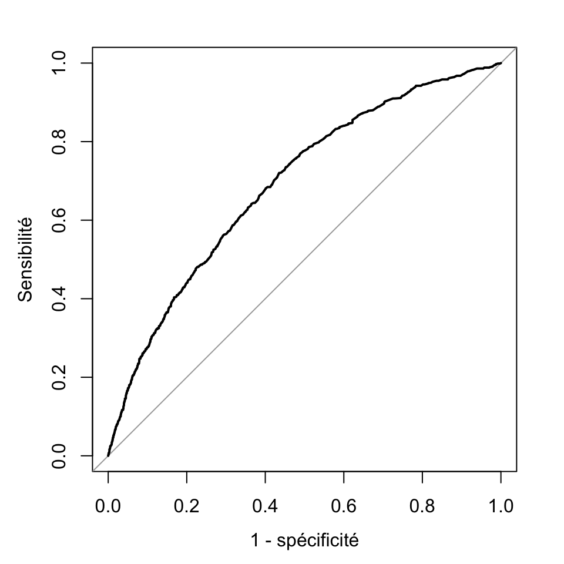

Courbe ROC du modèle logit final (hospitalisation, NMES 1988). Lecture : chaque point correspond à un seuil ; plus la courbe s’éloigne de la diagonale, mieux le modèle sépare hospitalisés et non hospitalisés.

```r
roc_sq <- roc(nmes$hosp, p_hat, quiet = TRUE)
plot(roc_sq, legacy.axes = TRUE, xlab = "1 - spécificité",
     ylab = "Sensibilité")
```

```r
auc_sq <- auc(roc_sq)
auc_sq
```

```
Area under the curve: 0.6917
```

1. **Seuil 0,5** : taux d’erreur 19,7 %, mais sensibilité de 4,9 % seulement (42 hospitalisés bien classés sur 865) pour une spécificité de 98,7 %. Le faible taux d’erreur est trompeur : prédire « jamais hospitalisé » pour tout le monde donnerait 19,6 % d’erreur, et le modèle ne fait pas mieux. Comme la prévalence est de 19,6 %, peu de probabilités prédites dépassent 0,5, et le modèle classe presque tout le monde en 0.
2. **Seuil = prévalence (0,196)** : la sensibilité monte à 60,7 % et la spécificité descend à 66,6 %. Le taux d’erreur augmente (34,5 %). Le choix du seuil est un arbitrage entre faux négatifs et faux positifs, qui dépend de leurs coûts respectifs (comme la règle à 0,7 du TD 2).
3. **AUC = 0,692** : en tirant au hasard un hospitalisé et un non hospitalisé, le modèle attribue la probabilité la plus élevée à l’hospitalisé dans 69 % des cas. C’est un pouvoir discriminant modeste. Les variables observées n’expliquent qu’une partie du risque d’hospitalisation.

**NoteBarème B6 (1,5)**

0,5 : tableau à 0,5 avec erreur, sensibilité et spécificité, et explication du faible nombre de prédits 1. 0,5 : seuil = prévalence et arbitrage. 0,5 : courbe ROC, AUC et interprétation.

### B7 : Probit [0,5]

> **Énoncé.** Réestimer le modèle final en probit. Comparer les coefficients des deux modèles (rapport logit/probit) et les conclusions.

**L’idée.** Logit et probit ne diffèrent que par la loi de l’erreur du modèle latent (logistique ou normale). Les coefficients sont exprimés dans l’unité de l’écart-type de cette erreur : ils ne sont pas comparables directement, mais leurs rapports, leurs signes et les probabilités prédites le sont.

```r
pr_sq <- glm(formula(l_sq), family = binomial(link = "probit"), data = nmes)
ratio <- coef(l_sq) / coef(pr_sq)
round(cbind(logit = coef(l_sq), p_logit = summary(l_sq)$coefficients[, 4],
            probit = coef(pr_sq), p_probit = summary(pr_sq)$coefficients[, 4],
            ratio = ratio), 3)
```

```
                 logit p_logit probit p_probit ratio
(Intercept)     -3.794   0.000 -2.237    0.000 1.696
healthpoor       0.576   0.000  0.346    0.000 1.664
healthexcellent -0.514   0.010 -0.261    0.011 1.971
chronic          0.504   0.000  0.276    0.000 1.827
I(chronic^2)    -0.042   0.004 -0.021    0.011 1.968
adllimited       0.371   0.000  0.220    0.000 1.682
age              0.196   0.002  0.116    0.001 1.688
gendermale       0.234   0.004  0.142    0.002 1.645
```

```r
c(AIC_logit = AIC(l_sq), AIC_probit = AIC(pr_sq))
```

```
 AIC_logit AIC_probit
  4065.054   4062.453
```

Les coefficients logit sont environ 1,7 fois plus grands que les coefficients probit (rapport compris entre 1,65 et 1,97 hors constante). Le rapport vient des échelles différentes des lois logistique (écart-type $\pi/\sqrt3 \approx 1{,}81$) et normale (1). En pratique le rapport est plus proche de 1,6–1,7 : les deux lois s’ajustent surtout au centre de la distribution, où leurs densités diffèrent d’un facteur d’environ 1,6, et non sur leur variance. Les signes, les significativités et les AIC (4 065,1 contre 4 062,5) sont très proches : **mêmes conclusions**.

**NoteBarème B7 (0,5)**

Rapport des coefficients (environ 1,6 à 2), explication par l’échelle des lois, conclusions identiques.

**AstuceÀ retenir (partie B)**

- Un **OR** multiplie une cote ; pour parler de probabilité, partir d’un $p_0$ et reconvertir. OR et rapport de probabilités ne se confondent que si l’événement est rare.
- **Wald** et **LR** sont équivalents en grand échantillon ; un test conjoint a autant de ddl que de contraintes.
- **Hosmer–Lemeshow** : observés contre attendus par groupes de risque ; un rejet invite à revoir la forme fonctionnelle.
- Avec un événement minoritaire, le seuil 0,5 donne un faible taux d’erreur mais une sensibilité quasi nulle : juger un modèle par l’AUC et choisir le seuil selon le coût des erreurs.
- Logit / probit : coefficients dans un rapport d’environ 1,6 à 2, mêmes conclusions.

# Partie C : Santé perçue [6 points]

**Le modèle.** La santé perçue a trois modalités **ordonnées**. Le logit ordonné suppose une variable **latente** continue $Y_i^* = X_i'\beta + \varepsilon_i$ (la « vraie » santé, non observée) et des **seuils** $\zeta_1 < \zeta_2$ qui la découpent en catégories. Un seul vecteur $\beta$ déplace toute la distribution de $Y_i^*$ : c’est l’hypothèse des **cotes proportionnelles**. Le logit multinomial, lui, ignore l’ordre et estime un vecteur de coefficients par modalité (hors référence).

**Ce que teste la partie.** Écrire et interpréter le modèle latent, calculer des probabilités à la main, tester l’hypothèse des cotes proportionnelles et comparer modèles ordonné et multinomial.

### C1 : Variable ordonnée [0,5]

> **Énoncé.** Créer une version **ordonnée** de `health`, nommée `health_o`, avec l’ordre `poor` < `average` < `excellent`, et donner sa distribution. Pourquoi un modèle ordonné est-il ici naturel ?

```r
nmes$health_o <- factor(nmes$health, levels = c("poor", "average", "excellent"),
                        ordered = TRUE)
table(nmes$health_o)
```

```
     poor   average excellent
      554      3509       343
```

```r
round(prop.table(table(nmes$health_o)), 3)
```

```
     poor   average excellent
    0.126     0.796     0.078
```

554 personnes en santé mauvaise, 3 509 moyenne et 343 excellente. Les modalités sont **ordonnées**. Un modèle ordonné exploite cet ordre avec un seul jeu de coefficients, au lieu de deux dans un multinomial.

**NoteBarème C1 (0,5)**

Facteur ordonné dans le bon ordre, distribution, justification.

### C2 : Logit ordonné [1,5]

> **Énoncé.** Ajuster un logit ordonné (`polr`) de `health_o` sur `chronic`, `adl`, `age`, `gender`, `school`, `income` et `afam`. Écrire le modèle (variable latente et seuils). Interpréter le signe des coefficients de `chronic` et `adl`. Interpréter l’odds ratio de `school`.

**L’idée.** Un coefficient positif **déplace vers la droite** la distribution de la santé latente : la masse passe des catégories basses vers les catégories hautes. Les seuils restent fixes. Le graphique ci-dessous montre le cas inverse (diminution de $X_i'\beta$).

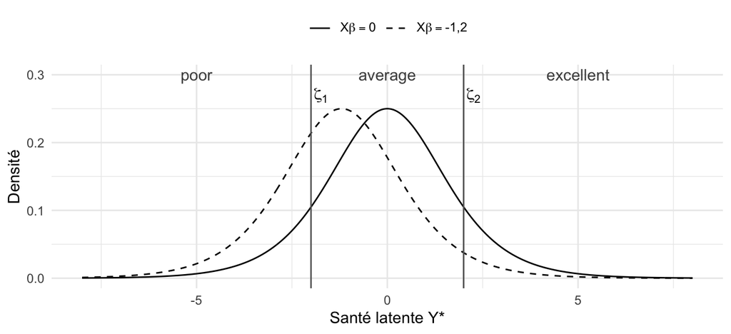

Logit ordonné : densité logistique de la santé latente $Y^*$ pour deux valeurs de $X\beta$, avec deux seuils illustratifs $\zeta_1$ et $\zeta_2$ (valeurs choisies pour le schéma, pas les estimations). Lecture : les aires sous la courbe entre les seuils donnent P(poor), P(average) et P(excellent). Diminuer $X\beta$ (une limitation fonctionnelle `adl`, par exemple) décale la courbe vers la gauche : P(poor) augmente et P(excellent) diminue.

```r
o_full <- polr(health_o ~ chronic + adl + age + gender + school + income + afam,
               data = nmes, Hess = TRUE)
ct_o <- coef(summary(o_full))
cbind(ct_o, p = 2 * pnorm(-abs(ct_o[, "t value"])))
```

```
                        Value Std. Error     t value            p
chronic           -0.58056985 0.03116329 -18.6299289 1.837684e-77
adllimited        -1.43728305 0.10414434 -13.8008754 2.517765e-43
age                0.03648907 0.06436816   0.5668808 5.707952e-01
gendermale        -0.04478092 0.08115487  -0.5517959 5.810882e-01
school             0.06905819 0.01136109   6.0784833 1.213246e-09
income             0.04250416 0.01304349   3.2586507 1.119434e-03
afamyes           -0.27683900 0.12449471  -2.2237008 2.616858e-02
poor|average      -2.57997881 0.50550496  -5.1037656 3.329607e-07
average|excellent  2.76757876 0.50395845   5.4916805 3.981273e-08
```

**Modèle.** On suppose une santé latente continue :

$$Y_i^* = X_i'\beta + \varepsilon_i, \qquad \varepsilon_i \sim \text{logistique},
\qquad
Y_i = \begin{cases}
\text{poor} & \text{si } Y_i^* \le \zeta_1 \\
\text{average} & \text{si } \zeta_1 < Y_i^* \le \zeta_2 \\
\text{excellent} & \text{si } Y_i^* > \zeta_2
\end{cases}$$

soit $\text{logit}\,P(Y_i \le j) = \zeta_j - X_i'\beta$ ($j = 1, 2$), sans constante dans $X_i'\beta$ : les seuils $\hat\zeta_1$ = -2,58 et $\hat\zeta_2$ = 2,77 en tiennent lieu. C’est la paramétrisation de `polr()`.

- **`chronic`** ($\hat\beta$ = -0,581) et **`adl`** ($\hat\beta$ = -1,437) sont négatifs : plus de maladies chroniques ou une limitation dans la vie quotidienne font baisser la santé latente, donc augmentent la probabilité de `poor` et diminuent celle de `excellent`.
- **`school`** : OR = $\exp(\hat\beta)$ = 1,071. Chaque année d’études supplémentaire multiplie par 1,071 la cote d’être dans une catégorie de santé **meilleure** plutôt que dans une catégorie inférieure, de la même façon aux deux seuils (average ou mieux contre poor ; excellent contre average ou moins). C’est l’hypothèse des cotes proportionnelles.

**AvertissementPiège fréquent**

Se tromper de signe. `polr()` écrit $\text{logit}\,P(Y \le j) = \zeta_j - X_i'\beta$ (signe moins) : un $\beta$ positif **diminue** la probabilité des catégories basses et augmente celle des catégories hautes. D’autres logiciels (et `clm()` pour les effets nominaux) utilisent des conventions différentes : toujours vérifier sur la documentation, ou sur une probabilité prédite.

**NoteBarème C2 (1,5)**

0,5 : modèle latent, seuils, paramétrisation (signe de $X_i'\beta$). 0,5 : signes de `chronic` et `adl` correctement traduits en probabilités des modalités extrêmes. 0,5 : OR de `school` interprété comme cote cumulative, identique aux deux seuils.

### C3 : Simplification [1]

> **Énoncé.** Tester par un test du rapport de vraisemblance la nullité conjointe des coefficients de `age` et `gender` (préciser les degrés de liberté). Quel modèle retient-on ?

**L’idée.** Même logique qu’en B4 : deux modèles emboîtés, un test LR, autant de ddl que de coefficients contraints à 0.

```r
o_red <- polr(health_o ~ chronic + adl + school + income + afam,
              data = nmes, Hess = TRUE)
lr_o <- anova(o_red, o_full)
lr_o
```

```
Likelihood ratio tests of ordinal regression models

Response: health_o
                                                  Model Resid. df Resid. Dev
1                chronic + adl + school + income + afam      4399   4769.578
2 chronic + adl + age + gender + school + income + afam      4397   4768.933
    Test    Df  LR stat.   Pr(Chi)
1
2 1 vs 2     2 0.6446314 0.7244694
```

LR = 0,64 pour **2 ddl** (deux coefficients contraints), p = 0,72. On ne rejette pas la nullité conjointe : à maladies, limitations, éducation et revenu donnés, l’âge et le sexe n’apportent pas d’information significative. On retient `health_o ~ chronic + adl + school + income + afam`.

**NoteBarème C3 (1)**

0,5 : test LR correct et 2 ddl justifiés. 0,5 : conclusion et modèle retenu.

### C4 : Probabilités prédites à la main [1]

> **Énoncé.** Avec le modèle retenu en C3, calculer **à la main** (à partir des coefficients et des seuils) les probabilités des trois modalités de santé pour une personne non afro-américaine, avec 2 maladies chroniques, sans limitation (`adl = normal`), 12 années d’études et un revenu familial de 25 000 dollars (si votre modèle conserve `age` et `gender`, prendre une femme de 74 ans). Vérifier avec `predict()`.

**L’idée.** La probabilité d’une modalité est l’aire entre deux seuils sur le graphique de C2, soit la différence de deux probabilités cumulées successives.

```r
b <- coef(o_red); z <- o_red$zeta
b; z
```

```
    chronic  adllimited      school      income     afamyes
-0.58071696 -1.41513426  0.06873049  0.04157267 -0.27607264
```

```
     poor|average average|excellent
        -2.833276          2.514726
```

```r
eta <- b["chronic"] * 2 + b["adllimited"] * 0 + b["school"] * 12 +
  b["income"] * 2.5 + b["afamyes"] * 0
p_main <- unname(c(plogis(z[1] - eta),
                   plogis(z[2] - eta) - plogis(z[1] - eta),
                   1 - plogis(z[2] - eta)))
names(p_main) <- c("poor", "average", "excellent")
profil <- data.frame(chronic = 2, adl = "normal", school = 12,
                     income = 2.5, afam = "no")
rbind(a_la_main = p_main, predict = predict(o_red, profil, type = "probs"))
```

```
                poor   average  excellent
a_la_main 0.06910369 0.8706662 0.06023012
predict   0.06910369 0.8706662 0.06023012
```

```r
# Erreur reportée : si age et gender sont conservés (femme de 74 ans)
predict(o_full, cbind(profil, age = 7.4, gender = "female"), type = "probs")
```

```
      poor    average  excellent
0.06762124 0.87079183 0.06158693
```

Avec les coefficients et les seuils **du modèle réduit** (et non ceux de C2, estimés avec `age` et `gender`) : $\hat\zeta_1$ = -2,833, $\hat\zeta_2$ = 2,515, et $X_i'\hat\beta$ = $2\hat\beta_{\text{chronic}} + 12\hat\beta_{\text{school}} + 2{,}5\,\hat\beta_{\text{income}}$ = -0,233 (les indicatrices `adl` et `afam` valent 0) :

- $P(\text{poor}) = \Lambda(\zeta_1 - X_i'\hat\beta)$ = 0,069 ;
- $P(\text{average}) = \Lambda(\zeta_2 - X_i'\hat\beta) - \Lambda(\zeta_1 - X_i'\hat\beta)$ = 0,871 ;
- $P(\text{excellent}) = 1 - \Lambda(\zeta_2 - X_i'\hat\beta)$ = 0,060,

avec $\Lambda$ la fonction logistique (`plogis`). `predict()` donne exactement les mêmes valeurs, et la somme vaut 1. Attention : `income` est en dizaines de milliers de dollars, donc 25 000 $ correspondent à `income = 2.5`.

**NoteBarème C4 (1)**

0,25 : $X_i'\hat\beta$ correct (bonne unité pour `income`, pas de constante). 0,5 : trois formules avec les seuils. 0,25 : vérification avec `predict()`.

### C5 : Cotes proportionnelles [1]

> **Énoncé.** Tester l’hypothèse des cotes proportionnelles variable par variable avec `ordinal::nominal_test()` appliquée au modèle de C3 réestimé avec `ordinal::clm()`. Conclure, et indiquer quelle conséquence en tirer pour la modélisation.

**L’idée.** Avec trois modalités, on peut poser deux questions binaires : « poor contre mieux » (seuil 1) et « au plus average contre excellent » (seuil 2). Le modèle ordonné impose qu’une variable ait le **même** effet (le même OR) dans les deux. Le test compare ce modèle à un modèle où l’effet de la variable peut différer d’un seuil à l’autre. Un rejet signifie que l’effet diffère d’un seuil à l’autre (par exemple, la variable joue surtout à un bout de l’échelle).

```r
clm_red <- clm(health_o ~ chronic + adl + school + income + afam, data = nmes)
nt <- nominal_test(clm_red)
nt
```

```
Tests of nominal effects

formula: health_o ~ chronic + adl + school + income + afam
        Df  logLik    AIC    LRT Pr(>Chi)
<none>     -2384.8 4783.6
chronic  1 -2384.3 4784.6 0.9382 0.332752
adl      1 -2380.2 4776.3 9.2487 0.002357 **
school   1 -2383.9 4783.8 1.7431 0.186747
income   1 -2384.6 4785.2 0.3829 0.536067
afam     1 -2384.3 4784.6 0.9501 0.329683
---
Signif. codes:  0 '***' 0.001 '**' 0.01 '*' 0.05 '.' 0.1 ' ' 1
```

```r
clm_ppo <- clm(health_o ~ chronic + school + income + afam, nominal = ~ adl,
               data = nmes)
coef(clm_ppo)[1:4]
```

```
     poor|average.(Intercept) average|excellent.(Intercept)
                   -2.8870138                     2.5526004
      poor|average.adllimited  average|excellent.adllimited
                    1.5146667                     0.7469295
```

```r
c(AIC_PO = AIC(clm_red), AIC_PPO = AIC(clm_ppo))
```

```
  AIC_PO  AIC_PPO
4783.578 4776.329
```

`clm()` estime le même modèle que `polr()`. `nominal_test()` compare, pour chaque variable, ce modèle à un modèle où l’effet de la variable peut différer d’un seuil à l’autre (test LR à 1 ddl, puisqu’il y a 2 seuils).

- **`adl`** : p = 0,002. On rejette l’hypothèse des cotes proportionnelles pour la limitation fonctionnelle.
- Autres variables : p de 0,19 à 0,54. Pas de rejet.

Dans le modèle à cotes **partiellement** proportionnelles (`nominal = ~ adl`), `adl` déplace les deux seuils de quantités différentes : un effet nominal s’ajoute au seuil, soit +1,51 au premier et +0,75 au second. Une limitation multiplie ainsi par 4,5 (exponentielle de 1,51) la cote d’être en **mauvaise** santé (plutôt que moyenne ou excellente), mais par 2,1 seulement (exponentielle de 0,75) la cote d’être en santé au plus moyenne (plutôt qu’excellente). La limitation fonctionnelle pèse surtout sur le risque de mauvaise santé. Le modèle à cotes proportionnelles impose un effet commun (1,42 à chaque seuil). L’AIC passe de 4 783,6 à 4 776,3.

**NoteBarème C5 (1)**

0,5 : test réalisé et lecture variable par variable (`adl` rejette, pas les autres). 0,5 : signification de l’hypothèse violée (effet différent selon le seuil) et conséquence (modèle partiellement proportionnel ou multinomial). Le modèle `clm_ppo` est un plus, non exigé.

### C6 : Multinomial contre ordonné [1]

> **Énoncé.** Ajuster un logit multinomial (`multinom`) avec les mêmes variables qu’en C3. Combien de paramètres compte chacun des deux modèles (ordonné et multinomial) ? Peut-on les comparer par un test du rapport de vraisemblance ? Comparer leurs AIC. Relier ce résultat à celui de C5.

**L’idée.** Un test LR exige que l’un des modèles soit un **cas particulier** de l’autre, obtenu en contraignant certains de ses paramètres. Sinon, on compare par un critère d’information (AIC), qui arbitre entre ajustement et nombre de paramètres.

```r
mn_red <- multinom(health_o ~ chronic + adl + school + income + afam,
                   data = nmes, trace = FALSE)
round(coef(mn_red), 3)
```

```
          (Intercept) chronic adllimited school income afamyes
average         2.623  -0.539     -1.488  0.075  0.051  -0.134
excellent       0.426  -1.159     -2.068  0.123  0.090  -0.655
```

```r
n_par <- c(ordonne = length(coef(o_red)) + length(o_red$zeta),
           multinomial = length(coef(mn_red)),
           partiel = length(coef(clm_ppo)))
n_par
```

```
    ordonne multinomial     partiel
          7          12           8
```

```r
c(AIC_ordonne = AIC(o_red), AIC_multinomial = AIC(mn_red),
  AIC_partiel = AIC(clm_ppo))
```

```
    AIC_ordonne AIC_multinomial     AIC_partiel
       4783.578        4775.941        4776.329
```

- **Paramètres** : ordonné = 5 pentes + 2 seuils = **7** ; multinomial = 2 équations de 6 paramètres (constante + 5 pentes) = **12** (référence `poor`).
- **Pas de test LR** : le logit ordonné n’est **pas un cas particulier** du logit multinomial (on ne l’obtient pas en contraignant certains paramètres du multinomial). Les deux modèles ne sont pas emboîtés, donc le test du rapport de vraisemblance n’a pas de loi connue. On compare par l’AIC.
- **AIC** : multinomial 4 775,9 contre ordonné 4 783,6. Le multinomial est préféré malgré ses 5 paramètres de plus. C’est cohérent avec C5 : l’hypothèse des cotes proportionnelles est violée (pour `adl`), et le multinomial, qui ne l’impose pas, s’ajuste mieux. Le modèle partiellement proportionnel atteint un AIC voisin (4 776,3) avec 8 paramètres seulement : c’est un bon compromis entre parcimonie et souplesse.

**NoteBarème C6 (1)**

0,25 : nombre de paramètres. 0,5 : non-emboîtement, donc AIC et pas de test LR (0 sur ce point si un test LR est présenté comme valide). 0,25 : lien avec C5.

**AstuceÀ retenir (partie C)**

- Logit ordonné : variable latente, seuils, **un seul** $\beta$ par variable ; attention à la convention de signe de `polr()`.
- Probabilité d’une modalité = différence de deux probabilités cumulées $\Lambda(\zeta_j - X_i'\beta)$.
- **Cotes proportionnelles** = même effet à chaque seuil ; à tester (`nominal_test`). Si rejet : effets nominaux pour les variables en cause (modèle partiel) ou multinomial.
- Ordonné et multinomial ne sont **pas emboîtés** : AIC, pas de test LR.

# Partie D (bonus) : Survie [4 points]

**Le modèle.** On observe une **durée** jusqu’au décès, souvent **censurée** : pour certains patients, on sait seulement qu’ils étaient vivants à la fin du suivi. Deux objets clés :

- la fonction de **survie** $S(t) = P(T > t)$, estimée sans modèle par Kaplan–Meier ;
- le **risque instantané** $h(t)$ : la probabilité de décéder juste après $t$, sachant qu’on est vivant en $t$ (par unité de temps).

Le modèle de Cox suppose $h_i(t) = h_0(t)\exp(X_i'\beta)$ : un risque de base $h_0(t)$ quelconque, multiplié par un facteur propre à chaque patient. $\exp(\beta_k)$ est le **hazard ratio** (HR). L’hypothèse clé est que ce rapport ne dépend pas du temps (**risques proportionnels**).

**Ce que teste la partie.** Censure, Kaplan–Meier et log-rank, Cox et son hypothèse de risques proportionnels, modèle paramétrique de Weibull.

### D1 : Objet de survie, censure [0,5]

> **Énoncé.** Créer l’objet de survie avec la fonction `Surv()` du package `survival` : `S_col <- Surv(colon_d$time, colon_d$status)`. Le premier argument est la durée observée (en jours) ; le second est l’indicateur d’événement (1 = décès observé, 0 = durée censurée). Afficher quelques valeurs de `S_col` : les durées censurées sont suivies d’un « + ». Quelle proportion des patients est censurée ? D’où vient la censure dans un essai thérapeutique ?

**L’idée.** Une durée censurée n’est pas une donnée manquante : elle apporte l’information « $T >$ durée observée ». La supprimer ou la traiter comme un décès biaiserait les estimations.

```r
S_col <- Surv(colon_d$time, colon_d$status)
head(S_col, 10)
```

```
 [1] 1521  3087+  963   293   659  1767   420  3192+ 3173+ 3308+
```

```r
c(n = nrow(colon_d), deces = sum(colon_d$status),
  part_censuree = mean(colon_d$status == 0))
```

```
            n         deces part_censuree
  911.0000000   441.0000000     0.5159166
```

```r
table(colon_d$rx)
```

```
    Obs     Lev Lev+5FU
    312     304     295
```

Dans l’affichage de `S_col`, une durée suivie d’un « + » est censurée : le patient était vivant à cette date, sans plus d’information. Sur 911 patients, 441 décès sont observés et **51,6 %** des durées sont censurées. Dans un essai, la censure est surtout **administrative** : les patients sont inclus à des dates différentes et l’analyse est arrêtée à une date commune, si bien que les derniers inclus ont un suivi plus court. Les perdus de vue s’y ajoutent. On suppose la censure **non informative**.

**NoteBarème D1 (0,5)**

L’objet `Surv` est fourni dans l’énoncé : les points portent sur la part censurée (0,25) et l’origine de la censure (administrative, non informative) (0,25).

### D2 : Kaplan–Meier et log-rank [1]

> **Énoncé.** Tracer les courbes de Kaplan–Meier par bras de traitement et donner les survies estimées à 5 ans (1 826 jours). Réaliser un test du log-rank : écrire $H_0$ et $H_1$, donner la statistique, ses degrés de liberté et la p-value, et conclure.

**L’idée.** Kaplan–Meier multiplie, à chaque date de décès, la probabilité de survivre à cette date parmi les patients encore suivis (« à risque ») : $\hat S(t) = \prod_{t_j \le t} (1 - d_j/n_j)$. Les censurés comptent parmi les patients à risque jusqu’à leur sortie. Le log-rank compare, à chaque date de décès, le nombre de décès observés dans chaque bras au nombre attendu si les bras avaient la même survie.

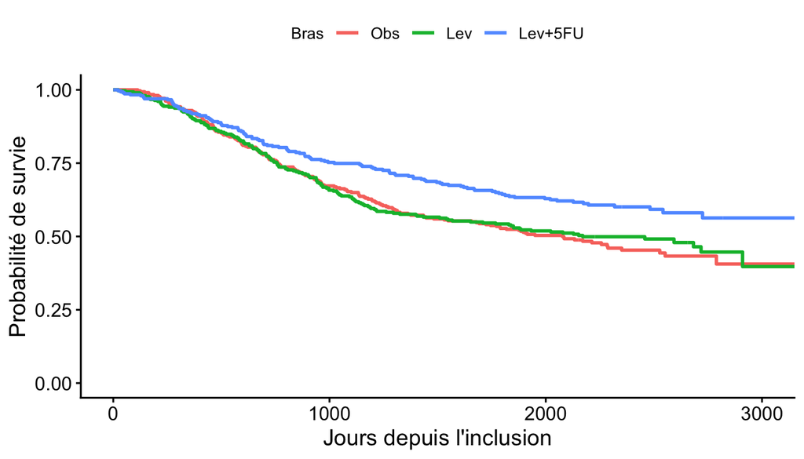

Survie globale de Kaplan–Meier par bras de traitement (essai NCCTG, cancer du côlon, décès). Lecture : proportion de patients encore en vie selon le temps écoulé depuis l’inclusion.

```r
km <- survfit(S_col ~ rx, data = colon_d)
ggsurvplot(km, data = colon_d, conf.int = FALSE, censor = FALSE,
           xlab = "Jours depuis l'inclusion", ylab = "Probabilité de survie",
           legend.title = "Bras", legend.labs = levels(colon_d$rx))
```

```r
s5 <- summary(km, times = 1826)$surv
names(s5) <- levels(colon_d$rx)
round(s5, 3)
```

```
    Obs     Lev Lev+5FU
  0.524   0.543   0.640
```

```r
lr <- survdiff(S_col ~ rx, data = colon_d)
lr
```

```
Call:
survdiff(formula = S_col ~ rx, data = colon_d)

             N Observed Expected (O-E)^2/E (O-E)^2/V
rx=Obs     312      167      146      3.07      4.59
rx=Lev     304      156      143      1.23      1.82
rx=Lev+5FU 295      118      152      7.76     11.89

 Chisq= 12.1  on 2 degrees of freedom, p= 0.002
```

```r
p_lr <- pchisq(lr$chisq, df = length(lr$n) - 1, lower.tail = FALSE)
```

- Survie à 5 ans : 52,4 % (observation), 54,3 % (lévamisole), **64,0 %** (lévamisole + 5-FU). Les trois courbes sont confondues la première année. Celle du bras `Lev+5FU` se détache ensuite et reste au-dessus des deux autres, elles-mêmes presque confondues.
- **Log-rank.** $H_0$ : $S_{\text{Obs}}(t) = S_{\text{Lev}}(t) = S_{\text{Lev+5FU}}(t)$ pour tout $t$ (mêmes fonctions de survie, ou de risque, dans les trois bras). $H_1$ : au moins deux bras diffèrent. $\chi^2$ = 12,08 pour **2 ddl** (3 groupes − 1), p = 0,0024. On rejette $H_0$ à 5 % : la survie diffère selon le traitement.

**NoteBarème D2 (1)**

0,25 : courbes de KM. 0,25 : survies à 5 ans. 0,5 : $H_0$ et $H_1$, statistique, 2 ddl, conclusion.

### D3 : Modèle de Cox [1]

> **Énoncé.** Ajuster un modèle de Cox avec `rx`, `nodes`, `extent`, `age` et `sex`. Interpréter le hazard ratio (rapport des risques instantanés) de `Lev+5FU` avec son intervalle de confiance. Le traitement étant tiré au sort, pourquoi ajuster quand même sur des caractéristiques des patients ? Donner au moins deux raisons.

**L’idée.** Un HR compare des **risques instantanés**, à chaque date, entre deux patients qui ne diffèrent que par la variable considérée. Ce n’est ni un rapport de probabilités de décès sur toute la période, ni un rapport de durées de survie.

```r
cox_col <- coxph(S_col ~ rx + nodes + extent + age + sex, data = colon_d)
hr <- summary(cox_col)$conf.int
round(hr, 3)
```

```
          exp(coef) exp(-coef) lower .95 upper .95
rxLev         0.916      1.092     0.736     1.140
rxLev+5FU     0.666      1.501     0.526     0.844
nodes         1.095      0.914     1.075     1.114
extent        1.706      0.586     1.371     2.123
age           1.006      0.994     0.998     1.014
sex           0.977      1.023     0.810     1.179
```

```r
cox_rx <- coxph(S_col ~ rx, data = colon_d)
round(summary(cox_rx)$conf.int, 3)
```

```
          exp(coef) exp(-coef) lower .95 upper .95
rxLev         0.954      1.048     0.767     1.187
rxLev+5FU     0.676      1.480     0.534     0.856
```

**HR de `Lev+5FU`** = 0,666 (IC 95 % : 0,526 à 0,844). À tout instant, le risque instantané de décès des patients traités par lévamisole + 5-FU est inférieur d’environ 33 % à celui des patients en simple observation, à ganglions, extension, âge et sexe donnés. Le lévamisole seul n’a pas d’effet significatif (HR = 0,916, IC 0,74 à 1,14). Comme le traitement est **tiré au sort**, on peut lire ce HR comme un **effet causal** du traitement, conditionnel au profil du patient (voir le point 3 ci-dessous).

**Pourquoi ajuster ?** Le tirage au sort rend l’effet non biaisé sans ajustement (HR non ajusté = 0,676). On ajuste quand même pour trois raisons :

1. **corriger les déséquilibres fortuits** entre bras sur des facteurs pronostiques forts (`nodes`, `extent`) ;
2. gagner en **précision**, car ces facteurs expliquent une grande part de la variabilité de la survie ;
3. le HR n’est pas **collapsible** : le HR conditionnel à des facteurs pronostiques diffère du HR marginal même sans confusion. L’ajusté est l’effet « à profil de patient donné ».

**NoteBarème D3 (1)**

0,5 : HR, IC et interprétation en risque instantané. 0,5 : rôle de la randomisation et raisons d’ajuster (au moins deux : déséquilibres fortuits, précision, non-collapsibilité).

### D4 : Risques proportionnels [1]

> **Énoncé.** Vérifier l’hypothèse des risques proportionnels graphiquement (courbes $\log(-\log \hat S(t))$ par bras) et par `cox.zph()`. Conclure.

**L’idée.** Sous l’hypothèse des risques proportionnels, $S_1(t) = S_0(t)^{\text{HR}}$. En prenant deux fois le logarithme, $\log(-\log S_1(t)) = \log(-\log S_0(t)) + \beta$ : les courbes $\log(-\log \hat S)$ des groupes sont **parallèles**, séparées d’un écart vertical constant égal à $\beta$. Des courbes qui se croisent nettement ou s’écartent avec le temps signalent un HR qui varie dans le temps. `cox.zph()` teste la même chose à partir des résidus de Schoenfeld : une pente non nulle dans le temps signale une violation.

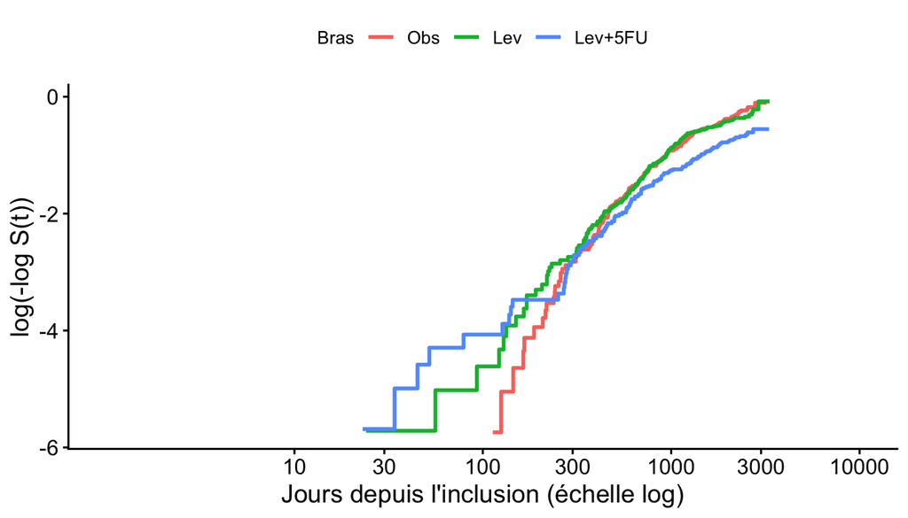

Courbes log(-log S(t)) de Kaplan–Meier par bras, en fonction du log du temps. Lecture : sous l’hypothèse des risques proportionnels, les courbes sont parallèles (écart vertical constant).

```r
ggsurvplot(km, data = colon_d, fun = "cloglog", censor = FALSE,
           xlab = "Jours depuis l'inclusion (échelle log)",
           ylab = "log(-log S(t))",
           legend.title = "Bras", legend.labs = levels(colon_d$rx))
```

```r
zph <- cox.zph(cox_col)
zph
```

```
        chisq df     p
rx     2.3410  2 0.310
nodes  0.0201  1 0.887
extent 3.2387  1 0.072
age    0.6072  1 0.436
sex    0.6862  1 0.407
GLOBAL 6.8917  6 0.331
```

- **Graphique** : les courbes de `Obs` et `Lev` se chevauchent (aucun effet détecté). Avant 300 jours environ, les courbes se croisent, mais elles reposent sur très peu de décès. Ensuite, la courbe de `Lev+5FU` reste sous les deux autres, avec un écart à peu près constant (il s’élargit un peu en fin de suivi). Le parallélisme est approximatif mais acceptable.
- **`cox.zph`** : p = 0,31 pour `rx`, p global = 0,33. Aucune variable ne rejette l’hypothèse des risques proportionnels.

Aucune violation des risques proportionnels n’est détectée : le modèle de Cox est plausible et le HR de D3 est un résumé raisonnable de l’effet du traitement sur la durée de suivi (`extent`, à p = 0,07, mériterait d’être surveillée).

**NoteBarème D4 (1)**

0,5 : lecture du graphique (parallélisme). 0,5 : `cox.zph`, p-values et conclusion.

### D5 : Weibull [0,5]

> **Énoncé.** Ajuster un modèle de Weibull (`survreg`) avec les mêmes variables. Interpréter le coefficient de `Lev+5FU` en rapport de durées et en déduire le hazard ratio implicite. Peut-on comparer l’AIC de ce modèle à celui du modèle de Cox ?

**L’idée.** Deux lectures d’un même effet. Le modèle à **temps de vie accéléré** (AFT) agit sur la durée : le traitement « étire » le temps de survie d’un facteur $\exp(\gamma)$. Le modèle à **risques proportionnels** agit sur le risque instantané. La Weibull (et son cas particulier, l’exponentielle) est la seule famille courante qui soit les deux à la fois : on passe de l’un à l’autre par $\beta = -\gamma/\sigma$. Le signe s’inverse : vivre plus longtemps (rapport de durées > 1) correspond à un risque plus faible (HR < 1).

```r
w_col <- survreg(S_col ~ rx + nodes + extent + age + sex, data = colon_d,
                 dist = "weibull")
round(summary(w_col)$table, 4)
```

```
              Value Std. Error        z      p
(Intercept) 10.0609     0.4078  24.6699 0.0000
rxLev        0.0892     0.1046   0.8522 0.3941
rxLev+5FU    0.4073     0.1135   3.5878 0.0003
nodes       -0.0897     0.0088 -10.1788 0.0000
extent      -0.4975     0.1051  -4.7331 0.0000
age         -0.0055     0.0038  -1.4502 0.1470
sex          0.0156     0.0897   0.1740 0.8619
Log(scale)  -0.0651     0.0425  -1.5317 0.1256
```

```r
g_trt <- coef(w_col)["rxLev+5FU"]
c(scale = w_col$scale, rapport_durees = exp(g_trt),
  HR_implicite = exp(-g_trt / w_col$scale))
```

```
                   scale rapport_durees.rxLev+5FU   HR_implicite.rxLev+5FU
               0.9369886                1.5027648                0.6474605
```

```r
c(AIC_Cox = AIC(cox_col), AIC_Weibull = AIC(w_col))
```

```
    AIC_Cox AIC_Weibull
   5599.923    7963.676
```

`survreg()` estime un modèle à **temps de vie accéléré** : $\log T = X\gamma + \sigma\,W$.

- $\hat\gamma_{\text{Lev+5FU}}$ = 0,407 : le traitement multiplie les durées de survie par $\exp(\hat\gamma)$ = **1,50** (rapport de durées).
- Avec $\hat\sigma$ = 0,937, le HR implicite vaut $\exp(-\hat\gamma/\hat\sigma)$ = **0,647**, très proche du HR de Cox (0,666). Les deux modèles concordent.
- **AIC** : on **ne peut pas** comparer 5 599,9 (Cox) et 7 963,7 (Weibull). L’AIC du Cox repose sur la vraisemblance **partielle**, celui de la Weibull sur la vraisemblance **complète**. Ce ne sont pas les mêmes quantités. L’AIC ne compare que des modèles estimés avec la même vraisemblance : des Cox entre eux (partielle, comme au TD 4) ou des modèles paramétriques entre eux (Weibull contre exponentielle, par exemple).

**NoteBarème D5 (0,5)**

0,25 : rapport de durées et HR implicite. 0,25 : AIC non comparables (vraisemblance partielle contre complète).

**AstuceÀ retenir (partie D)**

- Une durée **censurée** apporte l’information « $T >$ durée observée » : on la garde, on ne la traite ni comme manquante ni comme un décès.
- **HR** = rapport de risques instantanés (Cox) ; **rapport de durées** = effet sur le temps de survie (AFT). Pour une Weibull, $\beta = -\gamma/\sigma$ : un rapport de durées > 1 correspond à un HR < 1.
- Risques proportionnels : courbes $\log(-\log \hat S)$ parallèles et `cox.zph` non significatif.
- L’AIC d’un Cox (vraisemblance partielle) ne se compare pas à celui d’un modèle paramétrique.

# Synthèse : quel modèle, quel diagnostic

| Variable expliquée | Modèle | Lecture de $\exp(\beta)$ | Diagnostic clé | Piège principal |
| --- | --- | --- | --- | --- |
| Comptage (exposition variable) | Poisson + offset $\log n$ | ratio de taux (IRR) | déviance / Pearson sur données agrégées | oublier l’offset |
| Comptage sur-dispersé | binomiale négative | IRR | Pearson/ddl, AIC, zéros prédits | se fier aux p-values du Poisson |
| Binaire | logit ; probit | logit : rapport de cotes (OR) ; probit : signes et effets marginaux | Hosmer–Lemeshow, ROC / AUC | lire un OR comme un rapport de probabilités |
| Ordonnée | logit ordonné (`polr`, `clm`) | OR cumulatif, identique à chaque seuil | `nominal_test` (cotes proportionnelles) | convention de signe ; test LR contre le multinomial |
| Nominale | logit multinomial | OR par rapport à la modalité de référence | AIC | multiplier les paramètres sans nécessité |
| Durée censurée | Cox ; Weibull | hazard ratio ; rapport de durées (AFT) | $\log(-\log S)$, `cox.zph` | comparer l’AIC d’un Cox à celui d’une Weibull |

# Références

- Deb, P. et Trivedi, P. K. (1997). Demand for medical care by the elderly: a finite mixture approach. *Journal of Applied Econometrics*, 12(3), 313–336.
- Manning, W. G., Newhouse, J. P., Duan, N., Keeler, E. B., Leibowitz, A. et Marquis, M. S. (1987). Health insurance and the demand for medical care: evidence from a randomized experiment. *American Economic Review*, 77(3), 251–277.
- Moertel, C. G. et al. (1990). Levamisole and fluorouracil for adjuvant therapy of resected colon carcinoma. *New England Journal of Medicine*, 322(6), 352–358.
- Moertel, C. G. et al. (1995). Fluorouracil plus levamisole as effective adjuvant therapy after resection of stage III colon carcinoma: a final report. *Annals of Internal Medicine*, 122(5), 321–326.